# Introduction to Biostatistics

# 1 Learning objectives

## 1.1 Learning objectives

- *Interpret* tests comparing **two unrelated samples**
- *Summarize data* using **contingency tables**
- *Describe* different study designs for **contingency tables**

# 2 Two independent samples

## 2.1 Independent samples tests

- Compare **means** (or *medians*) from two *unrelated* samples
- Do the two samples come from populations with the same mean?
  - Is the difference between the two population means 0?

## 2.2 Independent samples tests

- Parametric tests
  - Independent samples $z$-test
  - Independent samples $t$-test (also Welch’s $t$-test)
- Non-parametric tests
  - Median test
  - Wilcoxon-Mann-Whitney U test
  - Chi-square test and Fisher’s exact test (*next week*)

## 2.3 Independence

- Statistical independence
  - Two events are **independent** if the occurrence of one event doesn’t impact the occurrence of another event
  - Knowing about one event tells you nothing about the other event
- Independent samples
  - Individuals in one sample are **not related** to individuals in the other sample
  - The two samples are made up of **different** individuals

## 2.4 $z$-test: Assumptions

- Data are **continuous** (i.e., ratio or interval)
- Data are **randomly sampled** from the population(s)
- Data are **independent** (*within* and *across* groups)
- Data are **approximately normally distributed OR** sample size is large enough for **normally distributed sampling distribution** (*central limit theorem*)
- Population variance (or SD) is **known** and **same in both groups**
  - “Large sample”: population variance estimated by sample variance

## 2.5 $z$-test: Hypotheses

- Directional (one-tailed) tests
  - $H_0$: $\mu_1 \le \mu_2$ or $\mu_1 - \mu_2 \le 0$
    - $H_1$: $\mu_1 > \mu_2$ or $\mu_1 - \mu_2 > 0$
  - $H_0$: $\mu_1 \ge \mu_2$ or $\mu_1 - \mu_2 \ge 0$
    - $H_1$: $\mu_1 < \mu_2$ or $\mu_1 - \mu_2 < 0$
- Non-directional (two-tailed) tests
  - $H_0$: $\mu_1 = \mu_2$ or $\mu_1 - \mu_2 = 0$
    - $H_1$: $\mu_1 \ne \mu_2$ or $\mu_1 - \mu_2 \ne 0$

## 2.6 $z$-test: Test statistic

$$z = \frac{(\bar{X_1} - \bar{X_2}) - (\mu_1 - \mu_2)}{\sqrt{\frac{\sigma^2_1}{n_1} + \frac{\sigma^2_2}{n_2}}}$$

- $\mu_1 - \mu_2 = 0$ (according to $H_0$)
- $\sigma^2_1$ and $\sigma^2_2$ are the variances of the two groups
- $n_1$ and $n_2$ are the sample sizes of the two groups

## 2.7 $z$-test: Example 1

- Is resting pulse rate the same for smokers and non-smokers?
  - One dataset / variable (column) for each group

```r
library(Stat2Data)
data(Pulse)
#head(Pulse)
library(tidyverse)
Pulse_smoke <- Pulse %>% filter(Smoke == 1)
Pulse_nosmoke <- Pulse %>% filter(Smoke == 0)
head(Pulse_smoke)
```

```
  Active Rest Smoke Sex Exercise Hgt Wgt
1     82   68     1   0        3  70 225
2     86   68     1   0        2  73 195
3     87   72     1   0        2  70 173
4    102   77     1   0        2  72 200
5     80   67     1   1        2  65 133
6     99   78     1   0        3  71 165
```

```r
head(Pulse_nosmoke)
```

```
  Active Rest Smoke Sex Exercise Hgt Wgt
1     97   78     0   1        1  63 119
2     88   62     0   0        3  72 175
3    106   74     0   0        3  72 170
4     78   63     0   1        3  67 125
5    109   65     0   0        3  74 188
6     66   43     0   1        3  67 140
```

## 2.8 $z$-test: Example 2

- Is resting pulse rate the same for smokers and non-smokers?
  - Check out the data

| Group | n | Mean | SD |
| --- | --- | --- | --- |
| Non-smokers | 206 | 67.791 | 9.851 |
| Smokers | 26 | 72.769 | 9.799 |

## 2.9 $z$-test: Example 3

- Is resting pulse rate the same for smokers and non-smokers?
  - Check out the data

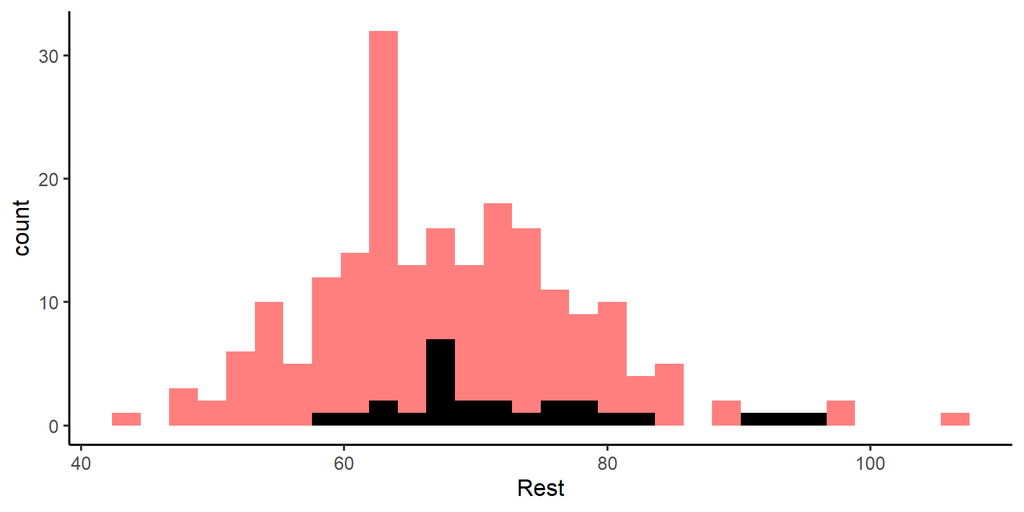

```r
ggplot(data = Pulse_nosmoke,
       aes(x = Rest)) +
  geom_histogram(fill = "red",
                 alpha = 0.5,
                 bins = 30) +
  geom_histogram(data = Pulse_smoke,
                 aes(x = Rest),
                 fill = "black",
                 bins = 30)
```

## 2.10 $z$-test: Example 4

- Is resting pulse rate the same for smokers and non-smokers?
  - `z.test()` function from **BSDA** package

```r
library(BSDA)
ztest <- z.test(x = Pulse_smoke$Rest,
                y = Pulse_nosmoke$Rest,
                sigma.x = sd(Pulse_smoke$Rest),
                sigma.y = sd(Pulse_nosmoke$Rest),
                alternative = "two.sided")
ztest
```

```
    Two-sample z-Test

data:  Pulse_smoke$Rest and Pulse_nosmoke$Rest
z = 2.4394, p-value = 0.01471
alternative hypothesis: true difference in means is not equal to 0
95 percent confidence interval:
 0.9783252 8.9776121
sample estimates:
mean of x mean of y
 72.76923  67.79126
```

## 2.11 $z$-test: Report results

- Reject $H_0$: $\mu_1 = \mu_2$ or $\mu_1 - \mu_2 = 0$
  - $p$-value < .05
  - 95% confidence interval doesn’t contain 0 (value from $H_0$)
  - These two samples came from *different* populations
- Using a two-sample $z$-test, we rejected the null hypothesis that the means are equal, $z$ = 2.44, $p$ = .01
  - Smokers and non-smokers have *different* resting pulse rates

## 2.12 $t$-test: Assumptions

- Data are **continuous** (i.e., ratio or interval)
- Data are **randomly sampled** from the population
- Data are **independent** (*within* and *across* groups)
- Data are **approximately normally distributed OR** sample size is large enough for **normally distributed sampling distribution** (*central limit theorem*)
- Population variance (or SD) is **unknown** and **same in both groups**

## 2.13 $t$-test: Hypotheses

- Directional (one-tailed) tests
  - $H_0$: $\mu_1 \le \mu_2$ or $\mu_1 - \mu_2 \le 0$
    - $H_1$: $\mu_1 > \mu_2$ or $\mu_1 - \mu_2 > 0$
  - $H_0$: $\mu_1 \ge \mu_2$ or $\mu_1 - \mu_2 \ge 0$
    - $H_1$: $\mu_1 < \mu_2$ or $\mu_1 - \mu_2 < 0$
- Non-directional (two-tailed) tests
  - $H_0$: $\mu_1 = \mu_2$ or $\mu_1 - \mu_2 = 0$
    - $H_1$: $\mu_1 \ne \mu_2$ or $\mu_1 - \mu_2 \ne 0$

## 2.14 $t$-test: Test statistic

$$t = \frac{(\bar{X_1} - \bar{X_2}) - (\mu_1 - \mu_2)}{\sqrt{\frac{s^2_p}{n_1} + \frac{s^2_p}{n_2}}}$$

- where $s^2_p = \frac{(n_1 -1)s^2_1 + (n_2 -1)s^2_2}{n_1 + n_2 -2}$
  - Assumes equal variances and pools (combines)
- with degrees of freedom = $n_1 + n_2 - 2$

## 2.15 $t$-test: Example 1

- Is resting pulse rate the same for smokers and non-smokers?
  - `t.test()` function from **stats** package

```r
ttest <- t.test(x = Pulse_smoke$Rest,
                y = Pulse_nosmoke$Rest,
                alternative = "two.sided",
                var.equal = TRUE)
ttest
```

```
    Two Sample t-test

data:  Pulse_smoke$Rest and Pulse_nosmoke$Rest
t = 2.4294, df = 230, p-value = 0.01589
alternative hypothesis: true difference in means is not equal to 0
95 percent confidence interval:
 0.9405909 9.0153463
sample estimates:
mean of x mean of y
 72.76923  67.79126
```

## 2.16 $t$-test: Report results

- Reject $H_0$: $\mu_1 = \mu_2$ or $\mu_1 - \mu_2 = 0$
  - $p$-value < .05
  - 95% confidence interval doesn’t contain 0 (value from $H_0$)
  - These two samples came from *different* populations
- Using a independent samples $t$-test, we rejected the null hypothesis that the means are equal, $t(230)$ = 2.43, $p$ = .02
  - Smokers and non-smokers have *different* resting pulse rates

## 2.17 Welch’s $t$-test: Unequal variances

$$t = \frac{(\bar{X_1} - \bar{X_2}) - (\mu_1 - \mu_2)}{\sqrt{\frac{s^2_1}{n_1} + \frac{s^2_2}{n_2}}}$$

- with degrees of freedom = **something much more complicated**
  - May be fractional

## 2.18 Welch’s $t$-test: Example

```r
welch <- t.test(x = Pulse_smoke$Rest,
                y = Pulse_nosmoke$Rest,
                alternative = "two.sided",
                var.equal = FALSE)
welch
```

```
    Welch Two Sample t-test

data:  Pulse_smoke$Rest and Pulse_nosmoke$Rest
t = 2.4394, df = 31.721, p-value = 0.02049
alternative hypothesis: true difference in means is not equal to 0
95 percent confidence interval:
 0.8198241 9.1361131
sample estimates:
mean of x mean of y
 72.76923  67.79126
```

## 2.19 Welch’s $t$-test: Report results

- Reject $H_0$: $\mu_1 = \mu_2$ or $\mu_1 - \mu_2 = 0$
  - $p$-value < .05
  - 95% confidence interval doesn’t contain 0 (value from $H_0$)
  - These two samples came from *different* populations
- Using a Welch’s $t$-test, we rejected the null hypothesis that the means are equal, $t(31.721)$ = 2.44, $p$ = .02
  - Smokers and non-smokers have *different* resting pulse rates

## 2.20 Very similar results

| Test | Diff | Statistic | df | $p$ | CI |
| --- | --- | --- | --- | --- | --- |
| $z$ | 4.978 | 2.439 | NA | 0.015 | [0.978, 8.978] |
| $t$ | 4.978 | 2.429 | 230 | 0.016 | [0.941, 9.015] |
| Welch | 4.978 | 2.439 | 31.721 | 0.02 | [0.82, 9.136] |

## 2.21 Non-parametric tests

- Non-parametric versions of $z$ or $t$-test for 2 independent samples
  - Median test
  - Wilcoxon-Mann-Whitney U test (or Mann-Whitney or Mann-Whitney-Wilcoxon)
- Differences in **median** (technically, “location”)
- Mann-Whitney is a somewhat better test

## 2.22 Non-parametric tests

- Median test

```r
library(coin)
median_test(Rest ~ as.factor(Smoke), data = Pulse)
```

```
    Asymptotic Two-Sample Brown-Mood Median Test

data:  Rest by as.factor(Smoke) (0, 1)
Z = -0.88412, p-value = 0.3766
alternative hypothesis: true mu is not equal to 0
```

- Wilcoxon-Mann-Whitney test

```r
wilcox.test(Rest ~ as.factor(Smoke), data = Pulse)
```

```
    Wilcoxon rank sum test with continuity correction

data:  Rest by as.factor(Smoke)
W = 1967, p-value = 0.02746
alternative hypothesis: true location shift is not equal to 0
```

# 3 Contingency tables

## 3.1 Contingency tables

- Cross-tabs, summary tables, 2x2 table
  - Relationship between two (or more) categorical variables
  - Each cell is a **frequency** for that combination
- `Sex` and `Smoke` from the `Pulse` dataset

```r
smoke_sex <- table(Pulse$Sex, Pulse$Smoke)
colnames(smoke_sex) <- c("Non-smoker", "Smoker")
rownames(smoke_sex) <- c("Male", "Female")
smoke_sex_margins <- addmargins(smoke_sex)
smoke_sex_prop_margins <- addmargins(prop.table(smoke_sex))
smoke_sex
```

```
         Non-smoker Smoker
  Male          105     17
  Female        101      9
```

## 3.2 Notation for frequencies

|  | $J = 1$ | $J = 2$ |  |
| --- | --- | --- | --- |
| $I = 1$ | $n_{11}$ | $n_{12}$ | $\color{white}{n_{1+}}$ |
| $I = 2$ | $n_{21}$ | $n_{22}$ |  |

## 3.3 Notation for frequencies

|  | $J = 1$ | $J = 2$ |  |
| --- | --- | --- | --- |
| $I = 1$ | $n_{11}$ | $n_{12}$ | $n_{1+}$ |
| $I = 2$ | $n_{21}$ | $n_{22}$ | $n_{2+}$ |
|  | $n_{+1}$ | $n_{+2}$ | $n$ |

- $n_{11}$, $n_{12}$, $n_{21}$, $n_{22}$ are **joint** frequencies
- $n_{1+}$, $n_{2+}$, $n_{+1}$, $n_{+2}$ are **marginal** frequencies

## 3.4 Notation for probabilities

|  | $J = 1$ | $J = 2$ |  |
| --- | --- | --- | --- |
| $I = 1$ | $p_{11}$ | $p_{12}$ | $\color{white}{p_{1+}}$ |
| $I = 2$ | $p_{21}$ | $p_{22}$ |  |

## 3.5 Notation for probabilities

|  | $J = 1$ | $J = 2$ |  |
| --- | --- | --- | --- |
| $I = 1$ | $p_{11}$ | $p_{12}$ | $p_{1+}$ |
| $I = 2$ | $p_{21}$ | $p_{22}$ | $p_{2+}$ |
|  | $p_{+1}$ | $p_{+2}$ | $1$ |

- $p_{11}$, $p_{12}$, $p_{21}$, $p_{22}$ are **joint** probabilities = $\frac{n_{ij}}{n}$
- $p_{1+}$, $p_{2+}$, $p_{+1}$, $p_{+2}$ are **marginal** probabilities = $\frac{n_{i+}}{n}$ or $\frac{n_{+j}}{n}$

## 3.6 Marginal probability

- **Marginal probability**: Probability of $X$ or $Y$, collapsing over the other
  - What is the distribution of $X$, ignoring $Y$?
  - What is the distribution of $Y$, ignoring $X$?

## 3.7 Marginal probability

- Start with frequencies

|  | $Y$ = 1: No smoke | $Y$ = 2: Smoke |  |
| --- | --- | --- | --- |
| $X = 1$: Male | $n_{11} = \color{red}{105}$ | $n_{12} = \color{red}{17}$ | $n_{1+} = \color{blue}{122}$ |
| $X = 2$: Female | $n_{21} = \color{red}{101}$ | $n_{22} = \color{red}{9}$ | $n_{2+} = \color{blue}{110}$ |
|  | $n_{+1} = \color{blue}{206}$ | $n_{+2} = \color{blue}{26}$ | $n = \color{blue}{232}$ |

## 3.8 Marginal probability

- Divide each value by $n$: The total sample size

|  | $Y$ = 1: No smoke | $Y$ = 2: Smoke |  |
| --- | --- | --- | --- |
| $X = 1$: Male | $p_{11} = \color{red}{0.45}$ | $p_{12} = \color{red}{0.07}$ | $p_{1+} = \color{blue}{0.53}$ |
| $X = 2$: Female | $p_{21} = \color{red}{0.44}$ | $p_{22} = \color{red}{0.04}$ | $p_{2+} = \color{blue}{0.47}$ |
|  | $p_{+1} = \color{blue}{0.89}$ | $p_{+2} = \color{blue}{0.11}$ | $p = \color{blue}{1}$ |

- $\color{red}{Joint}$ probabilities sum to 1
- $\color{blue}{Marginal}$ probabilities for *rows* sum to 1
- $\color{blue}{Marginal}$ probabilities for *columns* sum to 1

## 3.9 Conditional probability

- Often, $X$ is an explanatory variable, $Y$ is an outcome variable
  - **But it doesn’t need to be**
- **Conditional probability**: Probability of $Y$ **at a given value of $X$**
  - When $X = 1$, what is the distribution of $Y$?
  - When $X = 2$, what is the distribution of $Y$?
- Conditional probability is the $\color{red}{joint~value}$ divided by the $\color{blue}{marginal~value}$ **for that value of $X$**
  - It is **conditional** on that value of $X$

## 3.10 Conditional probability

|  | $Y$ = 1: No smoke | $Y$ = 2: Smoke |  |
| --- | --- | --- | --- |
| $X = 1$: Male | $n_{11} = \color{red}{105}$ | $n_{12} = \color{red}{17}$ | $n_{1+} = \color{blue}{122}$ |
| $X = 2$: Female | $n_{21} = \color{red}{101}$ | $n_{22} = \color{red}{9}$ | $n_{2+} = \color{blue}{110}$ |
|  | $n_{+1} = \color{blue}{206}$ | $n_{+2} = \color{blue}{26}$ | $n = \color{blue}{232}$ |

## 3.11 Conditional probability

|  | $Y$ = 1: No smoke | $Y$ = 2: Smoke |  |
| --- | --- | --- | --- |
| $X = 1$: Male | $n_{11} = \color{red}{105}$ | $n_{12} = \color{red}{17}$ | $n_{1+} = \color{blue}{122}$ |
| $X = 2$: Female | $n_{21} = \color{red}{101}$ | $n_{22} = \color{red}{9}$ | $n_{2+} = \color{blue}{110}$ |
|  | $n_{+1} = \color{blue}{206}$ | $n_{+2} = \color{blue}{26}$ | $n = \color{blue}{232}$ |

- When $X = 1$ (male):
  - $P(no\ smoke) = \frac{\color{red}{105}}{\color{blue}{122}} = 0.861$
  - $P(smoke) = \frac{\color{red}{17}}{\color{blue}{122}} = 0.139$
- When $X = 2$ (female):
  - $P(no\ smoke) = \frac{\color{red}{101}}{\color{blue}{110}} = 0.918$
  - $P(smoke) = \frac{\color{red}{9}}{\color{blue}{110}} = 0.082$

## 3.12 `Sex` and `Smoke`: Frequencies

```r
smoke_sex
```

```
         Non-smoker Smoker
  Male          105     17
  Female        101      9
```

## 3.13 `Sex` and `Smoke`: And margins

```r
smoke_sex_margins
```

```
         Non-smoker Smoker Sum
  Male          105     17 122
  Female        101      9 110
  Sum           206     26 232
```

## 3.14 `Sex` and `Smoke`: Marginal prob

```r
smoke_sex_prop_margins
```

```
         Non-smoker     Smoker        Sum
  Male   0.45258621 0.07327586 0.52586207
  Female 0.43534483 0.03879310 0.47413793
  Sum    0.88793103 0.11206897 1.00000000
```

## 3.15 `Sex` and `Smoke`: Conditional prob

```r
prop.table(smoke_sex, margin = 1)
```

```
         Non-smoker     Smoker
  Male   0.86065574 0.13934426
  Female 0.91818182 0.08181818
```

- Conditional on `Sex`

# 4 Study design

## 4.1 Fixed vs random

- The *marginal frequencies* of a contingency table can be either **fixed** or **random**
  - **Fixed**: Chosen by the researcher
    - e.g., Collect data on 50 men and 50 women
  - **Random**: Vary depending on the sample
    - e.g., Collect data on gender in the sample

## 4.2 Why do we care?

- **Probability** = random divided by fixed
  - If there are no fixed marginals, **we can’t calculate a probability**
- **Ratio** = random divided by random
  - We can always calculate ratios (e.g., odds ratios)
- What is “fixed” is what you can “condition on”
  - What are probabilities “out of”?

## 4.3 Why do we care?

- Design of the contingency table determines
  - What is **conditioned on**
  - What are **probabilities** (and what are just *ratios*)
  - How you can talk about the **relationship** in the table
  - What **statistical tests** you can perform

## 4.4 Types of study designs

- Three study designs with different fixed and random marginals
  - Cross-sectional (or multinomial)
  - Retrospective
  - Prospective (or product binomial)

## 4.5 Overall study design

|  | Heart attack | No heart attack | $\color{white}{White text}$ |
| --- | --- | --- | --- |
| Placebo |  |  |  |
| Aspirin |  |  |  |

- Relationship between aspirin use (vs placebo) and heart attack
  - $X$: Aspirin vs placebo
  - $Y$: Heart attack vs no heart attack

## 4.6 Cross-sectional

|  | Heart attack | No heart attack | $\color{white}{White text}$ |
| --- | --- | --- | --- |
| Placebo |  |  | Random |
| Aspirin |  |  | Random |
|  | Random | Random | **Fixed** |

- Collect data from $n$ people
  - Measure aspirin vs placebo, heart attack vs not

## 4.7 Retrospective

|  | Heart attack | No heart attack | $\color{white}{White text}$ |
| --- | --- | --- | --- |
| Placebo |  |  | Random |
| Aspirin |  |  | Random |
|  | **Fixed** | **Fixed** |  |

- Collect data from specific numbers of heart attack and non patients
  - Measure whether they took aspirin

## 4.8 Prospective

|  | Heart attack | No heart attack | $\color{white}{White text}$ |
| --- | --- | --- | --- |
| Placebo |  |  | **Fixed** |
| Aspirin |  |  | **Fixed** |
|  | Random | Random |  |

- Collect data from specific number of aspirin and placebo people
  - Measure whether they have a heart attack

## 4.9 `Smoke` and `Sex` example

- What type of study design was this?
  - Multinomial: Total $n$ is fixed
  - Retrospective: `Smoke` is fixed
  - Prospective: `Sex` is fixed

```r
smoke_sex_margins
```

```
         Non-smoker Smoker Sum
  Male          105     17 122
  Female        101      9 110
  Sum           206     26 232
```

## 4.10 Measures of relationship

- Any design
  - Odds ratio
  - Test of independence
- Prospective design only
  - Difference in proportion
  - Relative risk
  - Odds ratio
  - Test of independence

## 4.11 Difference in proportion

- If we assume it is a **prospective** design re: `Sex`
- Male
  - $P(smoke) = \frac{\color{red}{17}}{\color{blue}{122}} = 0.139$
- Female
  - $P(smoke) = \frac{\color{red}{9}}{\color{blue}{110}} = 0.082$
- Difference in proportion = $0.139 - 0.082 = 0.058$
  - A man is 5.8 percentage points more likely to be a smoker than a woman

## 4.12 Relative risk

- If we assume it is a **prospective** design re: `Sex`
- Male
  - $P(smoke) = \frac{\color{red}{17}}{\color{blue}{122}} = 0.139$
- Female
  - $P(smoke) = \frac{\color{red}{9}}{\color{blue}{110}} = 0.082$
- Relative risk = $\frac{0.139}{0.082} = 1.703$
  - A man is 1.703 times more likely to be a smoker than a woman

## 4.13 Odds ratio

$$odds(smoke) = P(smoke)/P(no\ smoke)$$

- Male
  - $P(smoke) = \frac{\color{red}{17}}{\color{blue}{122}} = 0.139$
  - $odds = \frac{0.139}{0.861} = 0.162$
- Female
  - $P(smoke) = \frac{\color{red}{9}}{\color{blue}{110}} = 0.082$
  - $odds = \frac{0.082}{0.918} = 0.089$
- $odds\ ratio = \frac{0.089}{0.162} = 0.55$
  - The **odds** of a woman smoking is 0.55 times the **odds** of a man smoking

## 4.14 Independence

- Do the **observed** frequencies match what we’d *expect* if the variables were **unrelated** or **independent**?
- Observed

```r
smoke_sex
```

```
         Non-smoker Smoker
  Male          105     17
  Female        101      9
```

- Expected (independence)

```r
library(epitools)
expected(smoke_sex)
```

```
         Non-smoker   Smoker
  Male    108.32759 13.67241
  Female   97.67241 12.32759
```

# 5 In-class activities

## 5.1 In-class activities

- Conduct two independent samples tests
  - $z$-test, $t$-test, Welch’s $t$-test
- Look at contingency tables and orient to them
- Think about study design

## 5.2 Next week

- Relate study design to tests for contingency tables
  - Some tests are only available for some designs
- Related-samples tests